# AIRbnb

Mathieu Lepoutre

19-10-2020

## Air BnB Mathieu Lepoutre

Op basis van data kunnen voorspellen naar welk land een nieuwe gebruiker zal gaan. Hier kan AirBnb dan op inspelen en gepersonaliseerdere content laten zien. Er zijn 195 landen, en correct kunnen voorspellen waar een nieuwe gebruiker naartoe gaat is een nieuwe bron van informatie waarmee AirBnb met om kan springen.

Er zijn twee soorten datasets. De train dataset is een dataset dat alle attributen bevat inclusief de country_destination, datgene wat we proberen te voorspellen. Bij de test dataset, is dit attribuut weggelaten en het is aan mij om te onderzoeken of ik dit accurraat kan voorspellen.

## Project analyse:

- Analyse van de probleemstelling
- Scheiden van afhankelijke en onafhankelijke variabelen
- Vastleggen performantie criteria
- Maak beslissingen rond levenscyclus

##Project uitvoering:

- Verzamelen van datasets
- Filteren, opkuisen en samenvoegen
- Randomiseren
- Trainen leeralgoritme
- Instellen hyperparameters
- Validatie
- Testen

**Verzamelen van datasets**

```r
train_data <- read.csv("train_users_2.csv")
```

```r
table(train_data$gender)
```

```
##
## -unknown-    FEMALE      MALE     OTHER
##     95688     63041     54440       282
```

Een eerste visualisatie is high level en dient om de proporties te laten zien.

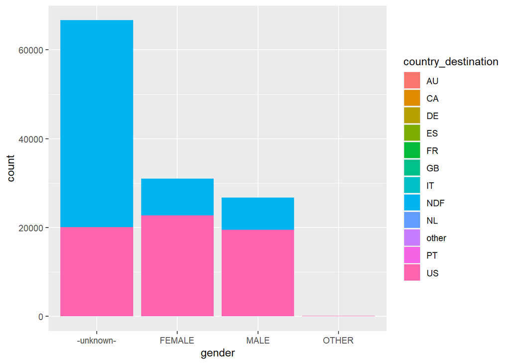

```r
ggplot(train_data, aes(gender, fill=country_destination)) +
    geom_bar(position="identity")
```

Zorgt de leeftijd voor veel variatie ?

```r
summary(train_data$age)
```

```
##    Min. 1st Qu.  Median    Mean 3rd Qu.    Max.    NA's
##    1.00   28.00   34.00   49.67   43.00 2014.00   87990
```

Een plot van de leeftijd.

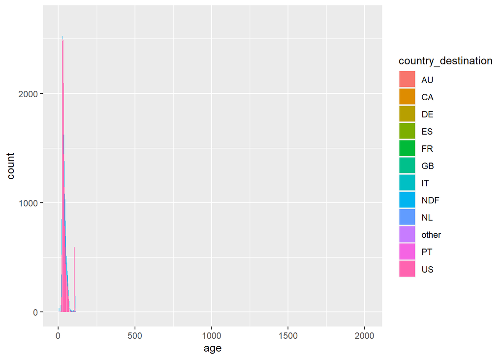

```r
ggplot(train_data, aes(age, fill=country_destination)) +
    geom_bar(position="identity")
```

Als voorspelling stel ik voor om de decision tree te gebruiken.